# JUDGE channel — III. Reliability & generalizability

12 LLMs as raters of adjective-pair judgments

ecb

2026-07-23

## Frame

Per ecb’s steer, the unit is **models as raters**: 12 judges each rate the same 136,503 unordered adjective pairs (symmetric similarity `S = (B[i,j]+B[j,i])/2`, justified in Report II). Reliability here is **inter-rater generalizability** — if we call the JUDGE similarity a *measurement*, how much of it is shared true score vs rater idiosyncrasy, and how many raters does a dependable measurement need? This is the psychometric spine of rgb’s “wisdom-of-crowds” observation (W16 §8b), made into variance components and a D-study.

Two measurement objects are analysed:

- **raw pair ratings** `S` — agreement on the endorsement level of each pair (includes the shared prevalence marginal from Report I);
- **double-centered** `S̃` — the marginal-free *similarity structure* (prevalence and anchor generosity swept out), a stricter “do raters agree on the personality covariance shape” test.

```r
sym <- fread_gz("sym_ev.csv.gz")
X <- as.matrix(sym[, ..MODELS])                 # pairs x raters (raw symmetric)
summ <- read_csv_("model_summary.csv") %>% as_tibble()
np <- nrow(X); nr <- ncol(X)
```

## 1. Variance components (G-theory, crossed pair × rater)

The design is fully crossed and balanced (every rater rates every pair once), so the random-effects variance components come straight from the ANOVA mean squares.

```r
gtheory <- function(X) {
  np<-nrow(X); nr<-ncol(X); grand<-mean(X)
  SSp<-nr*sum((rowMeans(X)-grand)^2); SSr<-np*sum((colMeans(X)-grand)^2)
  SSe<-sum((X-grand)^2)-SSp-SSr
  MSp<-SSp/(np-1); MSr<-SSr/(nr-1); MSe<-SSe/((np-1)*(nr-1))
  list(vp=(MSp-MSe)/nr, vr=(MSr-MSe)/np, ve=MSe)
}
vc <- gtheory(X)
tibble(Component=c("Pair (universe / true score)","Rater (leniency main effect)",
                   "Pair×Rater + error (residual)"),
       Variance=round(c(vc$vp,vc$vr,vc$ve),3),
       `% of total`=round(100*c(vc$vp,vc$vr,vc$ve)/sum(unlist(vc)),1)) %>%
  knitr::kable(caption="Generalizability variance components for the raw symmetric similarity.")
```

Generalizability variance components for the raw symmetric similarity.

| Component | Variance | % of total |
| --- | --- | --- |
| Pair (universe / true score) | 0.906 | 61.0 |
| Rater (leniency main effect) | 0.156 | 10.5 |
| Pair×Rater + error (residual) | 0.424 | 28.6 |

The **pair** facet dominates (≈61% of variance) — there is a large shared true-score signal every rater is tracking. The **rater/leniency** main effect (≈11%) is the response-style heterogeneity of Report I, now as a variance term; it depresses *absolute* agreement but is removed by design in a *relative* (consistency) coefficient. The residual (≈29%) is pair×rater interaction + measurement error — genuine disagreement about *which* pairs are similar.

```r
icc_from_vc <- function(vc, k) c(
  `ICC(2,1) abs, 1 rater` = vc$vp/(vc$vp+vc$vr+vc$ve),
  `ICC(2,k) abs, k raters`= vc$vp/(vc$vp+(vc$vr+vc$ve)/k),
  `ICC(3,1) consist, 1`   = vc$vp/(vc$vp+vc$ve),
  `ICC(3,k) consist, k`   = vc$vp/(vc$vp+vc$ve/k))
knitr::kable(round(t(t(icc_from_vc(vc, nr))),3), col.names="coefficient",
             caption=sprintf("Intraclass correlations (k = %d raters).", nr))
```

Intraclass correlations (k = 12 raters).

|  | coefficient |
| --- | --- |
| ICC(2,1) abs, 1 rater | 0.610 |
| ICC(2,k) abs, k raters | 0.949 |
| ICC(3,1) consist, 1 | 0.681 |
| ICC(3,k) consist, k | 0.962 |

- A **single LLM rater** has only *moderate* absolute agreement with the field (ICC(2,1) = 0.61). One model’s implicit personality theory is a noisy instrument.
- The **12-rater ensemble** is *excellent* (ICC(2,k) = 0.95) — the reliable measurement object is the **cohort consensus**, not any single model. This is precisely why rgb’s aggregate matches the human matrix above every individual model.
- Consistency exceeds agreement (0.68 > 0.61 single; 0.96 > 0.95 average): removing the leniency main effect recovers reliability, quantifying the calibration confound rgb flagged — **~0.07 of single-rater reliability is lost purely to differing scale use.**

## 2. D-study: how many raters do you need?

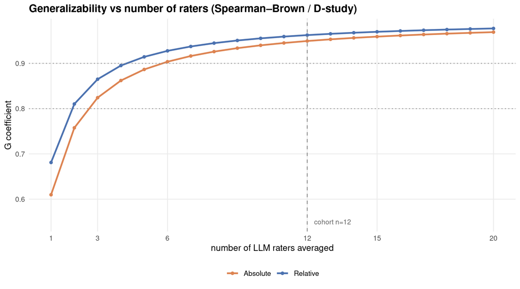

```r
ks <- 1:20
d <- tibble(k=ks,
            Relative =vc$vp/(vc$vp+vc$ve/ks),
            Absolute =vc$vp/(vc$vp+(vc$vr+vc$ve)/ks)) %>%
  pivot_longer(-k, names_to="coefficient", values_to="G")
ggplot(d, aes(k, G, colour=coefficient)) +
  geom_line(linewidth=1) + geom_point(size=1.4) +
  geom_hline(yintercept=c(.8,.9), linetype=3, colour="grey55") +
  geom_vline(xintercept=nr, linetype=2, colour="grey55") +
  annotate("text", x=nr+.3, y=.55, label="cohort n=12", hjust=0, size=3, colour="grey40") +
  scale_x_continuous(breaks=c(1,3,6,12,15,20)) +
  scale_colour_manual(values=c(Relative="#4C72B0", Absolute="#DD8452"), name=NULL) +
  labs(title="Generalizability vs number of raters (Spearman–Brown / D-study)",
       x="number of LLM raters averaged", y="G coefficient") +
  theme_judge()
```

```r
crossings <- sapply(c(.8,.9), function(t) min(which(vc$vp/(vc$vp+(vc$vr+vc$ve)/ks) >= t)))
cat(sprintf("Raters needed for absolute G≥0.8: %d; ≥0.9: %d.\n", crossings[1], crossings[2]))
```

```
## Raters needed for absolute G≥0.8: 3; ≥0.9: 6.
```

Dependability climbs steeply: ~3 raters for absolute G ≥ 0.8, ~6 for ≥ 0.9. The cohort of 12 is comfortably in the dependable range — but the curve also says a *handful* of well-chosen models would nearly suffice, so the ensemble’s value is real but saturating.

## 3. Rater quality is multidimensional — and the flat raters are *not* the bad ones

The tempting move is to score each rater by its correlation with the leave-one-out mean of the others and call the low scorers “bad.” Doing so on the **raw** ratings is misleading, because raw agreement is inflated by the shared prevalence marginal (every rater, even a flat one, reproduces the base-rate structure). So I score raters on three distinct axes: **information** (SD of ratings — differentiation), **between-rater agreement on structure** (leave-one-out correlation on the *double-centered*, prevalence-free similarity), and **within-rater consistency** (agreement of a rater’s two conditional directions, §5).

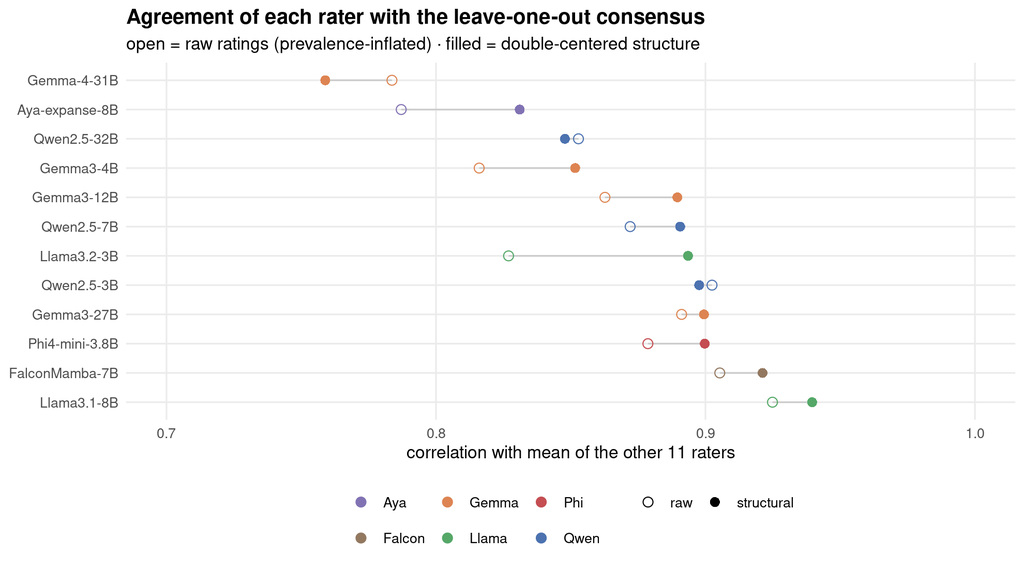

```r
loo_raw <- sapply(seq_len(nr), function(r) cor(X[,r], rowMeans(X[,-r])))
Sdc <- sapply(MODELS, function(m) upper_vec(double_center(build_matrix(sym, m, "sym"))))
loo_dc <- sapply(seq_len(nr), function(r) cor(Sdc[,r], rowMeans(Sdc[,-r])))
rq <- tibble(model=MODELS, display=DISPLAY[MODELS], family=FAMILY[MODELS],
             `raw`=loo_raw, `structural`=loo_dc,
             ev_sd=summ$ev_sd[match(MODELS,summ$model)])
rql <- rq %>% pivot_longer(c(raw, structural), names_to="metric", values_to="loo") %>%
  mutate(display=factor(display, levels=rev(rq$display[order(rq$structural)])))
ggplot(rql, aes(loo, display, colour=family, shape=metric)) +
  geom_line(aes(group=display), colour="grey80") +
  geom_point(size=2.6) + scale_colour_manual(values=FAM_PAL, name=NULL) +
  scale_shape_manual(values=c(raw=1, structural=16), name=NULL) +
  labs(title="Agreement of each rater with the leave-one-out consensus",
       subtitle="open = raw ratings (prevalence-inflated) · filled = double-centered structure",
       x="correlation with mean of the other 11 raters", y=NULL) +
  xlim(0.7,1) + theme_judge()
```

The ranking **inverts the naive expectation**. On the structural (marginal-free) metric the lowest agreers are the high-variance *idiosyncratic* models — **`Gemma-4-31B` (0.76) and `Aya` (0.83)** — while the flat non-discriminators **`FalconMamba` (0.92) and `Llama3.2-3B` (0.89) agree with the consensus *above average*.** A flat rater is a *compressed but faithful* image of the crowd (it tracks the shared structure, just with small amplitude); it is **low-information, not low-agreement, and not noisy.** So the “down-weight the non-responsive raters” intuition from Report I’s typology is, on the evidence, **wrong** — a correction worth stating plainly.

```r
disc  <- setdiff(MODELS, c("Llama","FalconMamba"))     # flat / low-information
idio  <- setdiff(MODELS, c("Gemma4","Aya"))            # idiosyncratic / low-agreement
vcF <- gtheory(as.matrix(sym[, ..disc])); vcI <- gtheory(as.matrix(sym[, ..idio]))
tibble(Ensemble=c("All 12 raters","drop 2 flat (Llama3.2, FalconMamba)",
                  "drop 2 idiosyncratic (Gemma-4, Aya)"),
       `ICC(2,1) single`=round(c(icc_from_vc(vc,nr)[1], icc_from_vc(vcF,length(disc))[1], icc_from_vc(vcI,length(idio))[1]),3),
       `pair var (true)`=round(c(vc$vp, vcF$vp, vcI$vp),3),
       `residual`       =round(c(vc$ve, vcF$ve, vcI$ve),3)) %>%
  knitr::kable(caption="Both trims raise single-rater ICC — by opposite mechanisms.")
```

Both trims raise single-rater ICC — by opposite mechanisms.

| Ensemble | ICC(2,1) single | pair var (true) | residual |
| --- | --- | --- | --- |
| All 12 raters | 0.610 | 0.906 | 0.424 |
| drop 2 flat (Llama3.2, FalconMamba) | 0.648 | 1.095 | 0.436 |
| drop 2 idiosyncratic (Gemma-4, Aya) | 0.630 | 0.879 | 0.354 |

Both trims *modestly* raise single-rater reliability, but for **opposite reasons**, which is the real lesson: dropping the **flat** raters raises reliability by **increasing pair (true-score) variance** (0.91→1.10 — the remaining raters differentiate more), whereas dropping the **idiosyncratic** raters raises it by **cutting the residual** (0.42→0.35 — less pair×rater disagreement). Neither is “removing noise”; they trade off different variance components. The 12-rater *ensemble* reliability is essentially untouched either way — the consensus is robust. Report V follows this up with a full consensus-construction study (competence- and confidence-weighting), whose punchline is previewed here: it buys almost nothing.

## 4. Which pairs are reliably vs idiosyncratically judged?

Centering each rater (removing leniency), the **between-rater SD of each pair** is its contestedness. Relating it to the consensus similarity level and to judgment entropy:

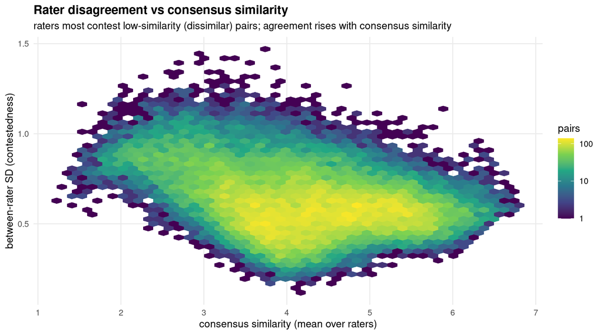

```r
Xc <- sweep(X, 2, colMeans(X))                 # remove rater leniency
pair_sd <- sqrt(rowMeans((Xc - rowMeans(Xc))^2) * nr/(nr-1))
cons <- rowMeans(X)
syh <- fread_gz("sym_hent.csv.gz")
pair_ent <- rowMeans(as.matrix(syh[, ..MODELS]))
pr <- data.table(i=sym$i, j=sym$j, cons=cons, disagree=pair_sd, ent=pair_ent)
set.seed(1)
ggplot(pr[sample(.N, 40000)], aes(cons, disagree)) +
  geom_hex(bins=45) + scale_fill_viridis_c(trans="log10", name="pairs") +
  labs(title="Rater disagreement vs consensus similarity",
       subtitle="raters most contest low-similarity (dissimilar) pairs; agreement rises with consensus similarity",
       x="consensus similarity (mean over raters)", y="between-rater SD (contestedness)") +
  theme_judge() + theme(legend.position="right")
```

```r
cat(sprintf("corr(disagreement, |consensus−midpoint|) = %.2f;  corr(disagreement, entropy) = %.2f\n",
    cor(pr$disagree, abs(pr$cons-4)), cor(pr$disagree, pr$ent)))
```

```
## corr(disagreement, |consensus−midpoint|) = 0.18;  corr(disagreement, entropy) = -0.24
```

The picture on the canonical data is **not** the inverted-U an earlier (12-model, EV-only) pass reported. Disagreement is **highest at the low-similarity end** (between-rater SD ≈ 0.85 for consensus 2–3) and **falls as consensus similarity rises** (≈ 0.60 for 5–7): raters broadly concur that clear synonyms co-occur, but **contest which traits are *dis*similar**. And contestedness **decreases** with per-judgment entropy (corr ≈ −0.24): the diffuse, hedged, mid-scale judgments (high entropy) are where raters *converge*, while the *confident* low-entropy judgments at the dissimilar end are where they diverge. So the unreliability sits in **confident negative judgments** — one rater’s “definitely not” is another’s “somewhat” — rather than in the middle. (Entropy still peaks mid-scale, as in Report I §3 — `corr(|consensus−4|, entropy) ≈ −0.8` — it is just *not* where the raters disagree.)

```r
pr[, `:=`(a_i=ADJ[i+1L], a_j=ADJ[j+1L])]
agree <- pr[cons>3 & cons<5][order(disagree)][1:8, .(pair=paste(a_i,"~",a_j), cons=round(cons,2), disagree=round(disagree,2))]
contest <- pr[order(-disagree)][1:8, .(pair=paste(a_i,"~",a_j), cons=round(cons,2), disagree=round(disagree,2))]
knitr::kable(list(agree, contest), caption="Most-agreed mid-similarity pairs (left) vs most-contested pairs (right).")
```

Most-agreed mid-similarity pairs (left) vs most-contested pairs (right).

| pair | cons | disagree |
| --- | --- | --- |
| religious ~ troubled | 4.32 | 0.12 |
| extraverted ~ unpredictable | 4.28 | 0.13 |
| lonely ~ realistic | 4.19 | 0.13 |
| generous ~ self-conscious | 4.08 | 0.15 |
| laughing ~ messy | 4.12 | 0.15 |
| playful ~ unsure | 4.20 | 0.15 |
| self-conscious ~ sociable | 3.67 | 0.15 |
| critical ~ decent | 4.13 | 0.15 |

| pair | cons | disagree |
| --- | --- | --- |
| overworked ~ unemployed | 2.99 | 1.65 |
| neglected ~ overrated | 4.08 | 1.54 |
| awake ~ feminine | 4.33 | 1.54 |
| experienced ~ senile | 3.12 | 1.53 |
| compatible ~ evil | 2.80 | 1.46 |
| feminine ~ lucky | 3.74 | 1.46 |
| feminine ~ guilty | 3.00 | 1.45 |
| afraid ~ brave | 3.97 | 1.45 |

## 5. Within-rater reliability: do the two directions agree?

A single rater gives two directed observations per pair, `B[i,j]` and `B[j,i]`. Their correlation is a **within-model** reliability of the symmetric score (a 2-observation internal consistency), Spearman–Brown-stepped-up to the averaged score:

```r
dir <- fread_gz("dir_ev.csv.gz")
# recover B[i,j] and B[j,i] by joining forward/backward keys
setkey(dir, i, j)
fwd <- dir[sym[, .(i,j)], on=.(i,j)]
bwd <- dir[sym[, .(j,i)], on=.(i=j, j=i)]
wr <- sapply(MODELS, function(m){
  r <- cor(fwd[[m]], bwd[[m]]); c(r=r, sb=2*r/(1+r))
})
wtab <- tibble(model=MODELS, display=DISPLAY[MODELS],
               `dir-dir r`=round(wr["r",],3), `Spearman–Brown`=round(wr["sb",],3),
               `ev_sd`=round(summ$ev_sd[match(MODELS,summ$model)],2)) %>% arrange(desc(`dir-dir r`))
knitr::kable(wtab, caption="Within-model agreement of the two conditional directions.")
```

Within-model agreement of the two conditional directions.

| model | display | dir-dir r | Spearman–Brown | ev_sd |
| --- | --- | --- | --- | --- |
| FalconMamba | FalconMamba-7B | 0.783 | 0.878 | 0.75 |
| Phi4 | Phi4-mini-3.8B | 0.648 | 0.787 | 1.72 |
| Gemma27 | Gemma3-27B | 0.636 | 0.778 | 1.40 |
| Llama8 | Llama3.1-8B | 0.594 | 0.745 | 1.02 |
| Qwen7 | Qwen2.5-7B | 0.593 | 0.745 | 1.14 |
| Qwen | Qwen2.5-3B | 0.592 | 0.744 | 1.64 |
| Gemma12 | Gemma3-12B | 0.567 | 0.724 | 1.21 |
| Qwen32 | Qwen2.5-32B | 0.534 | 0.696 | 1.09 |
| Gemma4 | Gemma-4-31B | 0.526 | 0.689 | 0.99 |
| Aya | Aya-expanse-8B | 0.524 | 0.688 | 1.95 |
| Llama | Llama3.2-3B | 0.506 | 0.672 | 0.46 |
| Gemma | Gemma3-4B | 0.475 | 0.644 | 1.46 |

The two directions correlate only **moderately (0.47–0.78; no rater reaches 0.8)** — so a *single* directed judgment is a noticeably noisy estimate of the underlying similarity, and averaging the two directions is a genuine reliability gain (Spearman–Brown steps 0.6 → ~0.75). This mirrors Report II: ~1/5 of each rater’s differentiated variance is direction-inconsistent. Crucially, the ordering is a **third, distinct axis** of rater quality — it does **not** track the flat/discriminating split: the flat `FalconMamba` is the *most* internally consistent rater (0.78 — a smooth, stable map), while the flat `Llama3.2-3B` (0.51) and the high-variance `Gemma3-4B`/`Aya` are the *least*. So within-, between-rater, and information axes each rank the raters differently; “flat” implies neither low agreement (§3) nor low within-rater consistency. Only `Llama3.2-3B` is weak on *both* variance and direction-consistency — the one rater whose scant signal is largely noise.

## 6. Structural agreement (marginal-free)

Repeating the headline inter-rater agreement on the **double-centered** similarity (prevalence + generosity swept out) — the strict “same covariance shape” test:

```r
Sdc <- sapply(MODELS, function(m){
  M <- build_matrix(sym, m, "sym"); upper_vec(double_center(M))
})
Craw <- cor(X); Cdc <- cor(Sdc)
tibble(Object=c("Raw symmetric ratings","Double-centered similarity"),
       `mean pairwise r`=round(c(mean(Craw[upper.tri(Craw)]), mean(Cdc[upper.tri(Cdc)])),3),
       `ICC(3,k) k=12` = c(round(icc_from_vc(vc,nr)[4],3), NA)) %>%
  knitr::kable(caption="Agreement stays high — indeed rises slightly — once shared marginals are removed.")
```

Agreement stays high — indeed rises slightly — once shared marginals are removed.

| Object | mean pairwise r | ICC(3,k) k=12 |
| --- | --- | --- |
| Raw symmetric ratings | 0.761 | 0.962 |
| Double-centered similarity | 0.790 | NA |

Notably, stripping the shared prevalence + generosity marginals does **not** lower agreement: mean pairwise r *rises* from 0.76 (raw) to 0.79 (double-centered). So the raters agree on the marginal-free *structure* even more than on the raw ratings — their shared signal is genuine co-occurrence covariance, not merely shared base rates, and the prevalence marginal is if anything a mild *locus* of between-rater disagreement (models differ modestly on which traits are universal). (The double-centered residual is the material Report IV factors.)

## Verdict

1. **A single LLM’s implicit personality theory is a moderately reliable instrument** (ICC(2,1) ≈ 0.61); the **dependable measurement is the cohort consensus** (ICC(2,k) ≈ 0.95). Treat “the JUDGE similarity” as an ensemble quantity.
2. **~3 good raters reach G ≥ 0.8** (~6 for ≥ 0.9); reliability saturates well before 12.
3. **The consensus is robust; don’t reflexively trim.** The flat raters (`Llama3.2-3B`, `FalconMamba`) *agree* with the crowd and don’t inject noise — they are low-information, not low-quality. The genuine (mild) outliers are the high-variance *idiosyncratic* models (`Gemma-4-31B`, `Aya`). Trimming either extreme nudges single-rater ICC via opposite variance mechanisms (dropping flat raters raises true-score variance; dropping idiosyncratic ones cuts the residual), but the ensemble reliability is essentially invariant and competence-weighting buys almost nothing (Report V), so the naive “down-weight the flat raters” intuition is unsupported.
4. **Disagreement lives at the *low-similarity, confident* end** — raters contest which traits are dissimilar and *converge* on hedged mid-scale judgments (contestedness falls with entropy). This corrects an earlier “contested middle” reading; the unreliability is still construct-located (definitional negatives are theory-laden), just at the opposite pole from where the two-moment pass suggested.
5. **~0.07 single-rater reliability is pure leniency confound** — removable, and a reason to prefer consistency-type coefficients (or to center raters) in any cross-model use. ```